# PRAKTIKUM KOMPUTASI STATISTIK MODUL 1

## 1. Lakukan barplot yang menampilkan gaji rata-rata Professor berdasarkan jabatan akademik

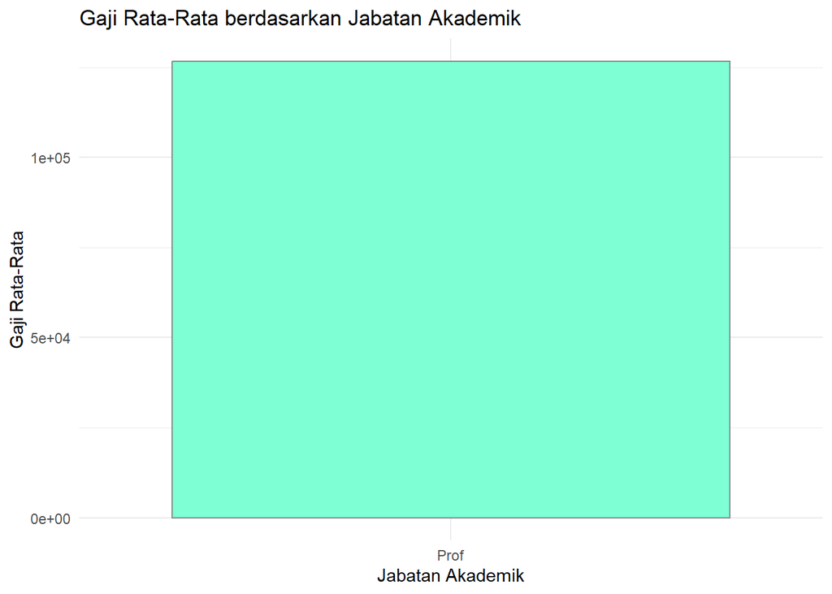

```r
ggplot(mean_salary_by_rank, aes(x=rank, y=mean_salary)) +
  geom_bar(stat="identity", fill="aquamarine", color="azure4") +
  labs(x="Jabatan Akademik", y="Gaji Rata-Rata", title="Gaji Rata-Rata berdasarkan Jabatan Akademik") +
  theme_minimal()
```

### 2. Lakukan boxplot yang menampilkan gaji rata-rata Professor berdasarkan jabatan akademik

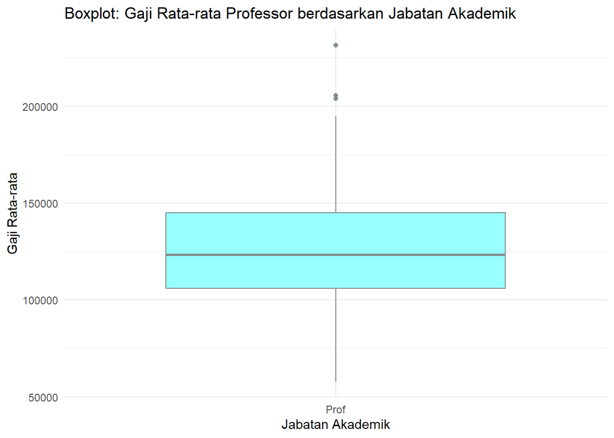

```r
ggplot(professors_data, aes(x=rank, y=salary)) +
  geom_boxplot(fill="darkslategray1", color="azure4") +
  labs(x="Jabatan Akademik", y="Gaji Rata-rata",
       title="Boxplot: Gaji Rata-rata Professor berdasarkan Jabatan Akademik") +
  theme_minimal()
```

Dalam situasi ini, kita mengandalkan ‘ggplot2’ untuk menghasilkan boxplot menggunakan ‘geom_boxplot()’. Boxplot ini bertujuan untuk menggambarkan distribusi gaji rata-rata profesor berdasarkan jabatan akademik tertentu, seperti ‘Prof’. Dalam boxplot tersebut, kita dapat melihat distribusi gaji rata-rata yang berkisar antara 100,000 hingga 150,000. Dengan menggunakan grafik ini, kita dapat dengan jelas memvisualisasikan pola distribusi gaji rata-rata profesor dengan jabatan akademik tertentu, terutama fokus pada rentang gaji di sekitar 100,000 hingga 150,000.